# Group 1 Report

Julian Cornea, Kim Ferres, Jan Löffelmann

23-05-2019

# 1 About the Data

The available data comes from an online shop, which sells beauty products. There are two datasets given: One with data about customer orders and another with data about customer clicks on the website.

The orders dataset consists of one row for each customer order in the time periode from the 28. January 2000 to the 3. March 2000. The data contains values such as the number of product units ordered, the total order amount, payment information, the manufacturer and brand names of the ordered products and social data about the customer, as by example his location or age.

The clicks dataset contains data referring to customer clicks on the website of the given company. Therefore, it is composed of data such as the timestamp of a click, the session length and the name of the clicked product, as well as the product category it belongs to. In this way the whole session course of a customer can be illustrated through the data.

Both datasets share a considerable amount of columns. However, since not every click results in an order and since a session consists normally of more than one click, the contents differ significantly.

# 2 Task Description

The project’s task is to analyze the dataset, especially by creating plots and statistical tables for the data, that is suspected to be relevant for the online shop in some way.

In addition to that the performance of different reccomendation systems has to be analyzed.

# 3 Cleaning the Data

Before we started cleaning the data, we copied it to the folder “0 Data”. The reason for this was to avoid accidentally altering the original dataset by separating the edited datasets from the original ones. The cleaned data and further forms of the datasets were also saved to this folder. Before explaining the cleaning process, it makes sense to get an overview of the content of the aforementioned folder. It can be described as follows:

- Each file has a suffix depending on what language was used for creating it. Files created with a Python script have the suffix “_P“, while files created with R have the suffix”_R“.
- For both datasets three types of files are created:
  - A copy of the original dataset (e.g. “order_data_R.csv”)
  - A cleaned version of that dataset (e.g. “order_data_cleaned_R.csv”)
  - A smaller version of the cleaned data, which allows quick viewing and testing of the technical functionality of the coding (e.g. “order_data_small_R.csv”)

## 3.1 Cleaning with R

The cleaning process consists of the following steps:

1. Copy the original datasets to the folder “0 Data”
2. Read the data, add headers (i.e. column labels), replace “?” and “NULL” with NA, drop columns which have a 100% ratio of missing data, reformat datetime cells and save the result (e.g. as “order_data_cleaned_R.csv”)
3. Create a subset of the cleaned data, containing only 1000 rows, and save it (e.g. as “order_data_small_R.csv”)

## 3.2 Cleaning with Python

A similar cleaning process to the one explained above has been implemented in Python. In the following block you can see the version in Python coding.

*Note: Python coding chunks are excutable in RMarkdown in general, but the Python environment is not persistent across different python chunks for the preview function ro run coding. Despite this, the chunks are compiled together, when the document is knitted.*

```python
import shutil
import pandas as pd

#paths
pathOrders = "orders/order_data.csv"
newPathOrders = "0 Data/order_data_P.csv"
pathOrdersClean = "0 Data/order_data_cleaned_P.csv"
pathOrdersSmall = "0 Data/order_data_small_P.csv"
pathOrdersHeaders = "orders/order_columns.txt"

pathClicks = "clickstream/clickstream_data.csv"
pathClicks2 = "clickstream/clickstream_data_part_2.csv"
newPathClicks = "0 Data/clickstream_data_P.csv"
pathClicksClean = "0 Data/clickstream_data_cleaned_P.csv"
pathClicksSmall = "0 Data/clickstream_data_small_P.csv"
pathClicksHeaders = "clickstream/clickstream_columns.txt"

#null values
nan = float('nan')

def headers(path):
    headers = open(path).\
              read().\
              split("\n")
    for counter, header in enumerate(headers):
        headers[counter] = (header.split(":"))[0]
        if not header: #for empty rows
            headers.pop(counter)
    return headers

def clean(df):
    #write NANs, delete empty columns
    df = df. \
         replace(to_replace="?", value=nan). \
         replace(to_replace="NULL", value=nan). \
         dropna(axis=1, how="all")
    #Clean Time and Date
    for column in df.columns:
        if "Time" in column:
            df[column] = df[column].\
                         str.\
                         replace('\\', '', regex=True)
    return df

# Copy files
shutil.copy(pathClicks, newPathClicks)
shutil.copy(pathOrders, newPathOrders)

pathOrders = newPathOrders
pathClicks = newPathClicks

# Read headers
clicksHeaders = headers(pathClicksHeaders)
ordersHeaders = headers(pathOrdersHeaders)

# Read data
clicks = pd.read_csv(pathClicks, sep=",", names=clicksHeaders, dtype=str, encoding="ISO-8859-1")
clicks2 = pd.read_csv(pathClicks2, sep=",", names=clicksHeaders, dtype=str, encoding="ISO-8859-1")
clicks = clean(clicks.append(clicks2))
orders = clean(pd.read_csv(pathOrders, sep=",", names=ordersHeaders, dtype=str, encoding="utf-8"))

# Save to CSV
clicks.to_csv(path_or_buf=pathClicksClean, index=False, encoding='utf-8')
(clicks.head(1000)).to_csv(path_or_buf=pathClicksSmall, index=False, encoding='utf-8')
orders.to_csv(path_or_buf=pathOrdersClean, index=False, encoding='utf-8')
(orders.head(1000)).to_csv(path_or_buf=pathOrdersSmall, index=False, encoding='utf-8')
```

## 3.3 Cleaning differences of Python and R

To test if the cleaning scripts in Python and R result in the same file, execute the following code in RStudio. The package creates a diff view

```r
library(diffobj)
pathOrders <- "0 Data/order_data_cleaned_R.csv"
pathClicks  <- "0 Data/clickstream_data_cleaned_R.csv"
pathOrdersPython <- "0 Data/order_data_cleaned_P.csv"
pathClicksPython  <- "0 Data/clickstream_data_cleaned_P.csv"

orders <- read.csv(file=pathOrders)
clicks <- read.csv(file=pathClicks)
clicksP = read.csv(file=pathClicksPython,na.strings=c("","NA"))
diffPrint(target=clicksP,current=clicks)
ordersP = read.csv(file=pathOrdersPython,na.strings=c("","NA"))
diffPrint(target=ordersP,current=orders)
```

## 3.4 Merging

Furthermore, we tried to merge the click and order data in Python by trying different ID combinations that occure in both datasets. For testing the different combinations we used an inner join in order to be able to recognize easier whether a merging try had success. We tried the following combinations for merging the two datasets, which resulted in the shown shapes for the merged dataset:

| Clicks | Orders | Shape |
| --- | --- | --- |
| Session ID | Order Line Session ID | [0, 438] |
| Session ID | Order Session ID | [0, 438] |
| Customer ID | Customer ID | [6906, 437] |
| Session Cookie ID | Order Line Session ID | [0, 438] |
| Session Cookie ID | Order Session ID | [0, 438] |

This way we were able to discover that it is possible to join on the ‘Customer ID’ for some instances. Thus, we saved a dataset for the merging results on the Customer ID:

```python
import pandas as pd

pathOrders = '../../0 Data/order_data_cleaned_P.csv'
pathClicks = '../../0 Data/clickstream_data_cleaned_P.csv'

pathMerge = "../../0 Data/merged_P.csv"
pathMergeSmall = "../../0 Data/merged_small_P.csv"

clicks = pd.read_csv(pathClicks, sep=",", dtype=str)
orders = pd.read_csv(pathOrders, sep=",", dtype=str)

# Merging
mergedData = pd.merge(clicks, orders, how='inner', left_on=['Customer ID'], right_on=['Customer ID'])

#Save CSV
mergedData.to_csv(path_or_buf=pathMerge, index=False)
(mergedData.head(10000)).to_csv(path_or_buf=pathMergeSmall, index=False)
```

# 4 Analyzing the Data

The aim of the data analysis is to extract information, which is suspected to be valuable to the online shop, and prepare it in a way that makes it easily “digestible”. The overview of the information is presented in statistical tables and plots.

## 4.1 Missing Data

Before creating overview tables or plots for columns, it makes sense to look which columns actually contain a large quantity of information and which do not. To do a check up on the ratio of filled cells, we created a ranking for both datasets containing column names and the percentage of missing data for each column. Columns with a low percentage of missing data are then preferred in later analysis steps. The first 50 entries in the resulting rankings can be seen in the following two tables.

| Column_Name | NA_percentage |
| --- | --- |
| Order.Line.Date | 0.0000 |
| Order.Line.Date_Time | 0.0000 |
| Order.Line.Unit.List.Price | 0.0000 |
| Order.Line.ID | 0.0000 |
| Order.Line.Quantity | 0.0000 |
| Order.Line.Unit.Sale.Price | 0.0000 |
| Order.Line.Status | 0.0000 |
| Order.Line.Tax.Amount | 0.0000 |
| Order.Line.Amount | 0.0000 |
| Order.Line.Day.of.Week | 0.0000 |
| Order.Line.Hour.of.Day | 0.0000 |
| City | 0.0000 |
| US.State | 0.0000 |
| Account.Creation.Date | 0.0000 |
| Account.Creation.Date_Time | 0.0000 |
| Account.Status | 0.0000 |
| Customer.ID | 0.0000 |
| Order.Date | 0.0000 |
| Order.Date_Time | 0.0000 |
| Order.Customer.ID | 0.0000 |
| Order.Modification.Date | 0.0000 |
| Order.Modification.Date_Time | 0.0000 |
| Order.System.Name | 0.0000 |
| Order.System.Number | 0.0000 |
| Order.ID | 0.0000 |
| Order.Source | 0.0000 |
| Order.Status | 0.0000 |
| Order.Amount | 0.0000 |
| Order.Shipping.Amount | 0.0000 |
| Order.Tax.Amount | 0.0000 |
| Order.Day.of.Week | 0.0000 |
| Order.Hour.of.Day | 0.0000 |
| Product.Hierarchy.Level | 0.0000 |
| Product.Object.ID | 0.0000 |
| Product.Object.Status | 0.0000 |
| Product.Creation.Date | 0.0000 |
| Product.Creation.Date_Time | 0.0000 |
| Product.Modification.Date | 0.0000 |
| Product.Modification.Date_Time | 0.0000 |
| Spend.Over..12.Per.Order.On.Average | 0.0000 |
| Order.Discount.Amount | 0.0020 |
| ActionCode | 0.0035 |
| Order.Line.Assortment.ID | 0.0063 |
| Order.Line.Subassortment.ID | 0.0063 |
| SendEmail | 0.0087 |
| Email | 0.0087 |
| Country | 0.0283 |
| Order.Num.Payments | 0.0447 |
| Legwear_size | 0.0494 |
| MyLegsColorRefNo1 | 0.0511 |

| Column_Name | NA_percentage |
| --- | --- |
| Request.Processing.Time | 0.0000 |
| Request.Date | 0.0000 |
| Request.Date_Time | 0.0000 |
| Request.Sequence | 0.0000 |
| Request.Template | 0.0000 |
| REQUEST_DAY_OF_WEEK | 0.0000 |
| REQUEST_HOUR_OF_DAY | 0.0000 |
| Cookie.First.Visit.Date | 0.0000 |
| Cookie.First.Visit.Date_Time | 0.0000 |
| Session.First.Request.Date | 0.0000 |
| Session.First.Request.Date_Time | 0.0000 |
| Session.Cookie.ID | 0.0000 |
| Session.ID | 0.0000 |
| Session.User.Agent | 0.0000 |
| Session.Visit.Count | 0.0000 |
| Session.First.Processing.Time | 0.0000 |
| Session.First.Template | 0.0000 |
| Session.First.Request.Day.of.Week | 0.0000 |
| Session.First.Request.Hour.of.Day | 0.0000 |
| Session.First.Content.ID | 0.0010 |
| Request.Assortment.ID | 0.0017 |
| Content.Level | 0.0067 |
| Content.Creation.Date | 0.0067 |
| Content.Creation.Date_Time | 0.0067 |
| Content.ID | 0.0067 |
| Content.Modification.Date | 0.0067 |
| Content.Modification.Date_Time | 0.0067 |
| Content.Status | 0.0067 |
| Content.Type | 0.0067 |
| Content.Level.1.Path | 0.0067 |
| Content.Level.2.Path | 0.0067 |
| Content.Level.3.Path | 0.0067 |
| Assortment.Type | 0.1764 |
| Assortment.ID | 0.1764 |
| Assortment.Status | 0.1764 |
| Assortment.Creation.Date | 0.1764 |
| Assortment.Creation.Date_Time | 0.1764 |
| Assortment.Modification.Date | 0.1764 |
| Assortment.Modification.Date_Time | 0.1764 |
| Assortment.Level | 0.1764 |
| Assortment.Level.1.Path | 0.1764 |
| Assortment.Level.2.Path | 0.1764 |
| Request.Query.String | 0.2248 |
| Request.Referrer | 0.2376 |
| Request.Subassortment.ID | 0.3006 |
| Session.First.Referrer | 0.4104 |
| Assortment.Level.3.Path | 0.4753 |
| Assortment.Level.4.Path | 0.6609 |
| Session.First.Query.String | 0.6713 |
| VendorPageColor | 0.7896 |

## 4.2 Structure and Content

### 4.2.1 Order Data

The order data can be mainly devided into 4 sections:

1. **Customer Data**: For this section we regard all information referring to the customer as an individual. This data contains information such as the customer gender, location, family status and retail activities.
   - City
   - Country
   - US.State
   - Age
   - Marital.Status
   - Gender
   - Audience
   - Truck.Owner
   - RV.Owner
   - Motorcycle.Owner
   - Working.Woman
   - Presence.Of.Children
   - Speciality.Store.Retail
   - Oil.Retail.Activity
   - Bank.Retail.Activity
   - Finance.Retail.Activity
   - Miscellaneous.Retail.Activity
   - Upscale.Retail
   - Upscale.Speciality.Retail
   - Retail.Activity
2. **Product Data**: The following data columns describe features of the ordered products.
   - StockType
   - Manufacturer
   - BrandName
3. **Payment Data**: This sections contains columns which describe the payment methods used by the customers.
   - Order.Credit.Card.Brand
   - Bank.Card.Holder
   - Gas.Card.Holder
   - Upscale.Card.Holder
   - Unknown.Card.Type
   - TE.Card.Holder
   - Premium.Card.Holder
   - New.Bank.Card
4. **Order Data**: The order data section contains information describing the order process itself, such as order quantity and price data.
   - Order.Line.Quantity
   - Order.Line.Unit.List.Price
   - Order.Line.Amount
   - Spend.Over..12.Per.Order.On.Average
   - Order.Line.Day.of.Week
   - Order.Line.Hour.of.Day
   - Order.Promotion.Code
   - Order.Discount.Amount

### 4.2.2 Clickstream Data

The clickstream data has three main categories:

1. **Customer Data**: The data contains a vast collection of information about customers, reaching from usual informations like age, gender, etc. over payment information and finacnial activities to opinions about the shop.
   - WhichDoYouWearMostFrequent
   - YourFavoriteLegcareBrand
   - Registration.Gender
   - NumberOfChildren
   - DoYouPurchaseForOthers
   - HowDoYouDressForWork
   - HowManyPairsDoYouPurchase
   - YourFavoriteLegwearBrand
   - WhoMakesPurchasesForYou
   - NumberOfAdults
   - HowDidYouHearAboutUs
   - SendEmail
   - HowOftenDoYouPurchase
   - HowDidYouFindUs
   - City
   - US.State
   - Year.of.Birth
   - Email
   - Truck.Owner
   - RV.Owner
   - Motorcycle.Owner
   - Value.Of.All.Vehicles
   - Age
   - Other.Indiv…Age
   - Marital.Status
   - Working.Woman
   - Mail.Responder
   - Bank.Card.Holder
   - Gas.Card.Holder
   - Upscale.Card.Holder
   - Unknown.Card.Type
   - TE.Card.Holder
   - Premium.Card.Holder
   - Presence.Of.Children
   - Number.Of.Adults
   - Estimated.Income.Code
   - Home.Market.Value
   - New.Car.Buyer
   - Vehicle.Lifestyle
   - Property.Type
   - Loan.To.Value.Percent
   - Presence.Of.Pool
   - Year.House.Was.Built
   - Own.Or.Rent.Home
   - Length.Of.Residence
   - Mail.Order.Buyer
   - Year.Home.Was.Bought
   - Home.Purchase.Date
   - Number.Of.Vehicles
   - DMA.No.Mail.Solicitation.Flag
   - DMA.No.Phone.Solicitation.Flag
   - CRA.Income.Classification
   - New.Bank.Card
   - Number.Of.Credit.Lines
   - Speciality.Store.Retail
   - Oil.Retail.Activity
   - Bank.Retail.Activity
   - Finance.Retail.Activity
   - Miscellaneous.Retail.Activity
   - Upscale.Retail
   - Upscale.Speciality.Retail
   - Retail.Activity
   - Dwelling.Size
   - Dataquick.Market.Code
   - Lendable.Home.Equity
   - Home.Size.Range
   - Lot.Size.Range
   - Insurance.Expiry.Month
   - Dwelling.Unit.Size
   - Month.Home.Was.Bought
   - Available.Home.Equity
   - Minority.Census.Tract
   - Year.Of.Structure
   - Gender
   - Occupation
   - Other.Indiv…Gender
   - Other.Indiv…Occupation
2. **Product Data**: The following data columns describe features of products clicked on by the customers.
   - BrandName
   - UnitsPerInnerBox
   - PrimaryPackage
   - Depth
   - VendorMinREOrderDollars
   - Height
   - UnitsPerOuterBox
   - StockType
   - Pack
   - ProductForm
   - Look
   - BasicOrFashion
   - MfgStyleCode
   - SaleOrNonSale
   - Length
   - MinQty
   - LeadTime
   - Weight
   - HasDressingRoom
   - ColorOrScent
   - Width
   - Texture
   - Manufacturer
   - ToeFeature
   - Category2
   - Material
   - CategoryCode
   - UnitIncrement
   - WaistControl
   - Collection
   - BodyFeature
   - Audience
   - Category1
   - Product
   - Pattern
3. **Time Data**: The following data columns describe different dates and times for clicks.
   - Request.Date
   - Request.Date_Time
   - Request.Sequence
   - REQUEST_DAY_OF_WEEK
   - REQUEST_HOUR_OF_DAY
   - Cookie.First.Visit.Date
   - Cookie.First.Visit.Date_Time
   - Session.First.Request.Date
   - Session.First.Request.Date_Time
   - Session.Start.Login.Count
   - Session.Cookie.ID
   - Session.ID
   - Session.Customer.ID
   - Session.Visit.Count
   - Session.First.Content.ID
   - Session.First.Request.Day.of.Week
   - Session.First.Request.Hour.of.Day

## 4.3 Statistical Tables

Given a subset of interesting columns, we create two types of statistical tables for each: One table for numerical columns in the subset and another for factors. The statistical table for the numerical data contains the maximum value, minimum value, mean, median and standard deviation for each column. Whereas the factorial tables contain the five most frequent factors as well as their percentage, the ratio of NAs and other factors for each column. For this, the NA percentage gets calculated at first, then the NA values are deleted from the regarded column and the percentage for each value is calcuated.

### 4.3.1 Order Data

In the following section the statistical tables generated for the purpose of describing the order data are shown. Additionally, the most important or interesting analysis results are emphasized and shortly explained.

*Note: To support a better visualization, more relevant columns columns are highligthed in red color.*

#### 4.3.1.1 Customer Data

Only the age can be regarded as a numerical customer data column here. As most intersting in this summary might appear the mean and the median, which both imply an average customer segment consisting of people in their late 30s.

| Variable | Max | Mean | Median | Min | SD |
| --- | --- | --- | --- | --- | --- |
| Age | 98 | 38.37 | 36 | 18 | 10.87 |

| Variable | Top.1st | Top.2nd | Top.3rd | Top.4th | Top.5th | Others | Not.Available |
| --- | --- | --- | --- | --- | --- | --- | --- |
| City | New York: 4.53% | San Francisco: 2.05% | Stamford: 1.24% | Austin: 1.13% | Brooklyn: 0.98% | 90.07% | 0% |
| Country | United States: 100% |  |  |  |  | 0% | 2.83% |
| US.State | CA: 14.63% | NY: 14.11% | TX: 6.93% | PA: 5.8% | CT: 5.28% | 53.25% | 0% |
| Marital.Status | Married: 66.13% | Single: 22.02% | Inferred Single: 7.15% | Inferred Married: 4.7% |  | 0% | 34.98% |
| Gender | Female: 83.06% | Male: 16.94% |  |  |  | 0% | 44.96% |
| Audience | Women: 81.17% | Men: 12.5% | Children: 6.33% |  |  | 0% | 11.08% |
| Truck.Owner | False: 78.55% | True: 21.45% |  |  |  | 0% | 22.22% |
| RV.Owner | False: 91.5% | True: 8.5% |  |  |  | 0% | 22.22% |
| Motorcycle.Owner | False: 98.66% | True: 1.34% |  |  |  | 0% | 22.22% |
| Working.Woman | False: 68.79% | True: 31.21% |  |  |  | 0% | 22.22% |
| Presence.Of.Children | False: 54.66% | True: 45.34% |  |  |  | 0% | 22.22% |
| Speciality.Store.Retail | False: 84.12% | True: 15.88% |  |  |  | 0% | 22.22% |
| Oil.Retail.Activity | False: 91.8% | True: 8.2% |  |  |  | 0% | 22.22% |
| Bank.Retail.Activity | False: 75.44% | True: 24.56% |  |  |  | 0% | 22.22% |
| Finance.Retail.Activity | False: 91.69% | True: 8.31% |  |  |  | 0% | 22.22% |
| Miscellaneous.Retail.Activity | False: 94.88% | True: 5.12% |  |  |  | 0% | 22.22% |
| Upscale.Retail | False: 94.25% | True: 5.75% |  |  |  | 0% | 22.22% |
| Upscale.Speciality.Retail | False: 96.44% | True: 3.56% |  |  |  | 0% | 22.22% |
| Retail.Activity | False: 60% | True: 40% |  |  |  | 0% | 22.22% |

#### 4.3.1.2 Product Data

The selected columns belonging to the product information section show only factorial values. The statistical overview for the product data reveals that most of the sold articles are replenishable. The strongest brand in the current orders is American Essential, which seems to manufacture its articles by itself. Important is to recognize that the presented data is biased in a way: Because the given dataset shows only ordered products, it can be assumed that the popularity of articles distorts all percentual information referring to the products. Thus, we can not make any assumptions referring to the original product palette the store offers.

| Variable | Top.1st | Top.2nd | Top.3rd | Top.4th | Top.5th | Others | Not.Available |
| --- | --- | --- | --- | --- | --- | --- | --- |
| StockType | Replenishable: 69.58% | Seasonal 1: 23.08% | Replenishment: 5.14% | Seasonal 1*: 1.83% | Seasonal 2: 0.24% | 0% | 14.72% |
| Manufacturer | American Essentials: 20.91% | Ridgeview: 16.64% | HAN: 13.16% | Donna Karan Company: 10.85% | HOSO: 10.67% | Peneco: 8.98% | 0% |
| BrandName | AME: 22.07% | HOSO: 11.26% | ELT: 10.81% | Silk Reflections: 9.35% | DAN: 7.92% | 27.51% | 11.08% |

#### 4.3.1.3 Payment Data

| Variable | Top.1st | Top.2nd | Top.3rd | Top.4th | Top.5th | Others | Not.Available |
| --- | --- | --- | --- | --- | --- | --- | --- |
| Order.Credit.Card.Brand | VISA: 59.94% | MC: 25.43% | AMEX: 14.31% | DISC: 0.31% | NA | 0% | 16.71% |
| Bank.Card.Holder | True: 86.57% | False: 13.43% |  |  | NA | 0% | 22.22% |
| Gas.Card.Holder | True: 75.81% | False: 24.19% |  |  | NA | 0% | 22.22% |
| Upscale.Card.Holder | True: 54.1% | False: 45.9% |  |  | NA | 0% | 22.22% |
| Unknown.Card.Type | False: 56.18% | True: 43.82% |  |  | NA | 0% | 22.22% |
| TE.Card.Holder | False: 89.42% | True: 10.58% |  |  | NA | 0% | 22.22% |
| Premium.Card.Holder | False: 75.88% | True: 24.12% |  |  | NA | 0% | 22.22% |
| New.Bank.Card | False: 99.55% | True: 0.45% |  |  | NA | 0% | 22.22% |

#### 4.3.1.4 Order Process Data

The numerical data for the order process shows that a customer usally buys one product per order. Also the order line amount implies that the store offers rather inexpensive articles. Furthermore, the minimum value for both the order line quantity and the order line amount is negative, which hints to the assumption of eather the order data containing returns as well or having errors in it. Through the discount amount it is possible to state that the store offers a maximum of a 50% price reduction for the given time period. Also the buyed articles got by average a discount of about 9%. Again it can be assumed that this data is not representative for the shop’s offer in general, because it is probable that articles with a higher discount are bought more often.

| Variable | Max | Mean | Median | Min | SD |
| --- | --- | --- | --- | --- | --- |
| Order.Line.Quantity | 18 | 1.31 | 1.0 | -2 | 0.95 |
| Order.Line.Unit.List.Price | 72 | 9.26 | 7.5 | 0 | 6.46 |
| Order.Line.Amount | 234 | 11.62 | 10.0 | -40 | 11.51 |
| Order.Line.Hour.of.Day | 23 | 13.04 | 13.0 | 0 | 5.29 |
| Order.Discount.Amount | 50 | 8.82 | 10.0 | 0 | 9.98 |

The factors for the order process demonstrate that the ‘FRIEND’ discount is used most often and in the majority of the orders. (At this point it would be relevant for the interpretation to know for whom and under which circumstances this discount is given.) Also the weekday summary could be relevant for sales purposes, by example for finding out the most successfull time for showing ads to possible customers.

| Variable | Top.1st | Top.2nd | Top.3rd | Top.4th | Top.5th | Others | Not.Available |
| --- | --- | --- | --- | --- | --- | --- | --- |
| Spend.Over..12.Per.Order.On.Average | False: 64.04% | True: 35.96% |  |  |  | 0% | 0% |
| Order.Line.Day.of.Week | Wednesday: 26.96% | Tuesday: 17.72% | Thursday: 17.37% | Friday: 16.48% | Saturday: 8.43% | 13.04% | 0% |
| Order.Promotion.Code | FRIEND: 82.09% | SPRING: 2.14% | MARCH1: 1.92% | FREE: 1.39% | 4128003160593466: 1.13% | 0% | 23.15% |

### 4.3.2 Clickstream Data

#### 4.3.2.1 Customer Data

| Variable | Top.1st | Top.2nd | Top.3rd | Top.4th | Top.5th | Others | Not.Available |
| --- | --- | --- | --- | --- | --- | --- | --- |
| WhichDoYouWearMostFrequent | casual socks: 37.12% | hosiery: 33.89% | athletic socks: 17.03% | trouser socks: 11.96% |  | 0% | 95.38% |
| YourFavoriteLegcareBrand | Nature Made: 13.58% | Conair: 13.51% | Epilady: 9.33% | Lucky Chick: 9.13% | DailyHerbs: 6.41% | 0% | 96.6% |
| Registration.Gender | Female: 59.52% | Male: 40.48% |  |  |  | 0% | 99.85% |
| NumberOfChildren | 0: 54.76% | 2: 18.25% | 4 or more: 13.89% | 1: 13.1% |  | 0% | 99.85% |
| DoYouPurchaseForOthers | False: 100% |  |  |  |  | 0% | 86.14% |
| HowDoYouDressForWork | business casual: 42.43% | very casual: 26.26% | business dress: 16.97% | comfortable / athletic: 14.34% |  | 0% | 95.46% |
| HowManyPairsDoYouPurchase | 15 or more: 55.78% | 11 to 15: 25.65% | 1 to 5: 13.01% | 6 to 10: 5.56% |  | 0% | 95.59% |
| YourFavoriteLegwearBrand | Hanes: 36.85% | DKNY: 16.21% | Danskin: 8.67% | Donna Karan: 8.22% | Berkshire: 6.6% | 0% | 95.42% |
| WhoMakesPurchasesForYou | spouse: 41.29% | friend: 30.15% | parent: 28.22% | siblings: 0.35% |  | 0% | 99.12% |
| NumberOfAdults | 2: 35.71% | 3 or more: 34.13% | 1: 30.16% |  |  | 0% | 99.85% |
| HowDidYouHearAboutUs | other: 38.81% | friend / family: 31.82% | e-mail: 16.02% | print ad: 11.58% | in the news: 1.22% | 0% | 87.9% |
| SendEmail | True: 66.3% | False: 33.7% |  |  |  | 0% | 85.98% |
| HowOftenDoYouPurchase | every 6 months: 77.96% | once a year: 14.1% | each week: 7.94% |  |  | 0% | 96.38% |
| HowDidYouFindUs | Friend/Co-worker: 59.92% | Other: 26.98% | News Story: 13.1% |  |  | 0% | 99.85% |
| City | New York: 2.36% | Dallas: 1.35% | San Francisco: 1.31% | Stamford;: 1.22% | stamford: 1.01% | 6.77% | 85.98% |
| US.State | NY: 12.7% | CA: 12.55% | TX: 6.37% | CT: 5.83% | PA: 5.17% | 0% | 85.98% |
| Email | COM: 72.94% | NET: 20.09% | EDU: 2.57% | Other: 2.07% | Gazelle: 1.81% | 0% | 85.98% |
| Truck.Owner | False: 79.26% | True: 20.74% |  |  |  | 0% | 89.44% |
| RV.Owner | False: 92.23% | True: 7.77% |  |  |  | 0% | 89.44% |
| Motorcycle.Owner | False: 98.83% | True: 1.17% |  |  |  | 0% | 89.44% |
| Marital.Status | Married: 59.26% | Single: 27.16% | Inferred Married: 6.83% | Inferred Single: 6.75% |  | 0% | 90.97% |
| Working.Woman | False: 67.26% | True: 32.74% |  |  |  | 0% | 89.44% |
| Mail.Responder | True: 73.6% | False: 26.4% |  |  |  | 0% | 89.44% |
| Bank.Card.Holder | True: 81.44% | False: 18.56% |  |  |  | 0% | 89.44% |
| Gas.Card.Holder | True: 68.95% | False: 31.05% |  |  |  | 0% | 89.44% |
| Upscale.Card.Holder | False: 50.88% | True: 49.12% |  |  |  | 0% | 89.44% |
| Unknown.Card.Type | False: 59.71% | True: 40.29% |  |  |  | 0% | 89.44% |
| TE.Card.Holder | False: 90.67% | True: 9.33% |  |  |  | 0% | 89.44% |
| Premium.Card.Holder | False: 79.92% | True: 20.08% |  |  |  | 0% | 89.44% |
| Presence.Of.Children | False: 53.25% | True: 46.75% |  |  |  | 0% | 89.44% |
| Estimated.Income.Code | $50;000-$74;999: 21.33% | $75;000-$99;999: 18.36% | $40;000-$49;999: 13.19% | $125;000 OR MORE: 10.72% | $30;000-$39;999: 10.43% | 0% | 89.71% |
| Home.Market.Value | $50;000-$74;999: 16.65% | $100;000-$124;999: 13.96% | $75;000-$99;999: 13.33% | $150;000-$174;999: 8.32% | $125;000-$149;999: 8.16% | 0% | 92.22% |
| New.Car.Buyer | True: 100% |  |  |  |  | 0% | 95.32% |
| Vehicle.Lifestyle | IMPORT (STANDARD/ECONOMY): 26.06% | FULL SIZE (STANDARD/LUXURY): 24.07% | TRUCK OR UTILITY VEHICLE: 12.16% | SPECIALTY (MIDSIZE/SMALL): 11.19% | STATION WAGON: 9.65% | 0% | 95.48% |
| Property.Type | single family dwelling: 84.34% | condo: 10.98% | 2-4 unit(duplex;triplex;quad): 2.23% | misc. residential (condo store/flat): 1.69% | apartment(5+ units): 0.68% | 0% | 96.15% |
| Loan.To.Value.Percent | 0% (NO LOANS): 29.12% | 70-74%: 9.97% | 100-99%: 9.22% | 60-69%: 9.04% | 01-49%: 7.9% | 0% | 97.33% |
| Presence.Of.Pool | False: 98.25% | True: 1.75% |  |  |  | 0% | 89.44% |
| Own.Or.Rent.Home | Owner: 94.76% | Renter: 5.24% |  |  |  | 0% | 90.68% |
| Mail.Order.Buyer | True: 61.3% | False: 38.7% |  |  |  | 0% | 89.44% |
| DMA.No.Mail.Solicitation.Flag | True: 100% |  |  |  |  | 0% | 89.44% |
| DMA.No.Phone.Solicitation.Flag | True: 100% |  |  |  |  | 0% | 89.44% |
| New.Bank.Card | False: 100% |  |  |  |  | 0% | 89.44% |
| Speciality.Store.Retail | False: 86.93% | True: 13.07% |  |  |  | 0% | 89.44% |
| Oil.Retail.Activity | False: 90.19% | True: 9.81% |  |  |  | 0% | 89.44% |
| Bank.Retail.Activity | False: 78.38% | True: 21.62% |  |  |  | 0% | 89.44% |
| Finance.Retail.Activity | False: 91.41% | True: 8.59% |  |  |  | 0% | 89.44% |
| Miscellaneous.Retail.Activity | False: 94.05% | True: 5.95% |  |  |  | 0% | 89.44% |
| Upscale.Retail | False: 94.59% | True: 5.41% |  |  |  | 0% | 89.44% |
| Upscale.Speciality.Retail | False: 97.06% | True: 2.94% |  |  |  | 0% | 89.44% |
| Retail.Activity | False: 64.38% | True: 35.62% |  |  |  | 0% | 89.44% |
| Dwelling.Size | SINGLE HOUSEHOLD: 74.42% | 2 HOUSEHOLDS: 7.48% | 100+ HOUSEHOLDS: 3.4% | 10-19 HOUSEHOLDS: 2.65% | 30-39 HOUSEHOLDS: 2.17% | 0% | 90.16% |
| Lendable.Home.Equity | EQUITY LESS THAN OR EQUAL $0: 29.99% | EQUITY $10;000-$19;9999: 11.73% | EQUITY $30;000-$49;000: 10.5% | EQUITY $75;000-$99;999: 8.58% | EQUITY $100;000-$149;999: 7.92% | 0% | 97.33% |
| Home.Size.Range | 1;250-1;499 FT: 17.76% | 1;000-1;249 FT: 15.73% | 750-999 FT: 12.85% | 2;000-2;499 FT: 12.51% | 1;500-1;749 FT: 10.59% | 0% | 97.13% |
| Lot.Size.Range | 1 ACRE OR LESS: 88.42% | GREATER THAN 1 ACRE: 11.58% |  |  |  | 0% | 97.51% |
| Dwelling.Unit.Size | SINGLE FAMILY DWELLING UNIT: 74.4% | MULTI FAMILY DWELLING UNIT: 25.6% |  |  |  | 0% | 89.9% |
| Available.Home.Equity | EQUITY $30;000-$49;000: 19.28% | EQUITY $50;000-$74;000: 18.7% | EQUITY $100;000-$149;999: 12.29% | EQUITY $20;000-$29;000: 11.46% | EQUITY $75;000-$99;999: 10.96% | 0% | 91.8% |
| Minority.Census.Tract | False: 99.04% | True: 0.96% |  |  |  | 0% | 89.44% |
| Gender | Female: 82.35% | Male: 17.65% |  |  |  | 0% | 92.91% |
| Occupation | PROFESSIONAL/TECHNICAL: 27.42% | HOUSEWIFE: 16.64% | ADMINISTRATIVE/MANAGERIAL: 14.35% | CLERICAL/WHITE COLLAR: 11.61% | STUDENT: 6.24% | 0% | 96.62% |
| Other.Indiv…Gender | Male: 79.08% | Female: 20.92% |  |  |  | 0% | 94.8% |
| Other.Indiv…Occupation | PROFESSIONAL/TECHNICAL: 44.18% | ADMINISTRATIVE/MANAGERIAL: 18% | CRAFTSMAN/BLUE COLLAR: 14.53% | SALES/SERVICE: 5.2% | CLERICAL/WHITE COLLAR: 5.01% | 0% | 97.07% |

| Variable | Max | Mean | Median | Min | SD |
| --- | --- | --- | --- | --- | --- |
| Year.of.Birth | 1979 | 1963.63 | 1962 | 1948 | 8.88 |
| Value.Of.All.Vehicles | 99000 | 18863.13 | 16000 | 1000 | 13401.19 |
| Age | 86 | 37.58 | 36 | 18 | 10.56 |
| Other.Indiv…Age | 86 | 40.37 | 38 | 18 | 10.56 |
| Number.Of.Adults | 6 | 2.52 | 2 | 1 | 1.35 |
| Year.House.Was.Built | 1997 | 1965.16 | 1969 | 1850 | 25.23 |
| Length.Of.Residence | 15 | 6.77 | 6 | 0 | 4.38 |
| Year.Home.Was.Bought | 1999 | 1991.18 | 1993 | 1954 | 6.34 |
| Home.Purchase.Date | 199906 | 199121.02 | 199300 | 195400 | 633.68 |
| Number.Of.Vehicles | 3 | 1.45 | 1 | 1 | 0.59 |
| CRA.Income.Classification | 4 | 3.33 | 3 | 1 | 0.64 |
| Number.Of.Credit.Lines | 9 | 2.60 | 3 | 1 | 1.56 |
| Dataquick.Market.Code | 10 | 4.45 | 4 | 1 | 2.45 |
| Insurance.Expiry.Month | 12 | 6.51 | 6 | 1 | 3.46 |
| Month.Home.Was.Bought | 12 | 7.12 | 7 | 1 | 3.28 |
| Year.Of.Structure | 1999 | 1972.74 | 1981 | 1900 | 27.69 |

#### 4.3.2.2 Product Data

| Variable | Top.1st | Top.2nd | Top.3rd | Top.4th | Top.5th | Others | Not.Available |
| --- | --- | --- | --- | --- | --- | --- | --- |
| BrandName | DKNY: 9.99% | Silk Reflections: 9.21% | ORO: 8.85% | HPK: 7.22% | AME: 7.13% | 0% | 86.16% |
| PrimaryPackage | Bottle: 35.18% | Tube: 30.46% | Jar: 25.55% | Box: 5.4% | Spray: 3.41% | 0% | 96.07% |
| StockType | Replenishable: 60.93% | Seasonal 1: 23.75% | Seasonal 1*: 11.25% | Seasonal 2: 2.07% | Replenishment: 1.83% | 0% | 80.3% |
| ProductForm | Cream: 54.01% | Liquid: 24.19% | gel: 7.58% | Lotion: 7.36% | Capsule: 5.97% | 0% | 96.64% |
| Look | Sheer: 83.41% | Ultra Sheer: 13.1% | Opaque: 3.48% |  |  | 0% | 94.22% |
| BasicOrFashion | Basic: 92.33% | Fashion: 7.67% |  |  |  | 0% | 86.11% |
| MfgStyleCode | Tricot: 2.34% | BC27340: 1.45% | 00N02: 1.35% | 00Q63: 1.34% | 5751: 1.2% | 10.26% | 82.06% |
| SaleOrNonSale | NSALE: 100% |  |  |  |  | 0% | 94.46% |
| HasDressingRoom | False: 73.56% | True: 26.44% |  |  |  | 0% | 86.09% |
| ColorOrScent | Scent: 85.69% | Color: 14.31% |  |  |  | 0% | 99.7% |
| Texture | Flat: 66.48% | Textured: 33.52% |  |  |  | 0% | 96.65% |
| Manufacturer | Donna Karan Company: 10.79% | Peneco: 9.08% | HAN: 8.66% | Kneipp: 6.61% | Paul Lavitt Mills Inc.: 6.54% | 0% | 80.12% |
| ToeFeature | SF: 86.04% | RT: 13.96% |  |  |  | 0% | 93.49% |
| Category2 | Gift Sets & Special Items: 32.01% | Skincare: 23.28% | Cellulite & Other Treatments: 22.82% | Footcare: 14.47% | Health Supplements: 6.2% | 0% | 99.21% |
| Material | Cotton: 66.35% | Nylon: 23.62% | Coolmax: 3.71% | Rayon: 1.49% | Lycra: 1.04% | 0% | 93.18% |
| CategoryCode | PH: 33.89% | WDCS: 12.66% | TH: 7.83% | FO: 6.76% | TT: 6.2% | 0% | 86.09% |
| WaistControl | CT: 76.17% | STW: 23.83% |  |  |  | 0% | 94.34% |
| Collection | Oroblu Italian Hosiery: 6.31% | Conversationals: 5.17% | DKNY Skin: 4.41% | Action Pack 3-Pair: 3.9% | Womens Dance: 3.84% | 0% | 86.96% |
| BodyFeature | MBC: 64.5% | UBC: 17.51% | LBC: 11.17% | BS: 6.82% |  | 0% | 98.49% |
| Audience | Women: 80.86% | Men: 10.21% | Children: 8.93% |  |  | 0% | 86.09% |
| Category1 | Skincare: 60.62% | Footcare: 18.05% | Cellulite & Other Treatments: 15% | Hair Removal: 3.89% | Health Supplements: 1.83% | 0% | 94% |
| Product | Cellulite Trimming Gel: 3.25% | Body Lotion - Oceanic Minerals: 2.74% | Kit-Firming Cream/Slimming Cream/Shorts: 2.57% | Body Silk: 2.41% | Herbal Foot Balm: 2.31% | 0% | 94% |
| Pattern | Solid: 58% | Conversational: 39.12% | Floral: 2.03% | Stripe: 0.55% | Herringbone: 0.18% | 0% | 93.72% |

| Variable | Max | Mean | Median | Min | SD |
| --- | --- | --- | --- | --- | --- |
| UnitsPerInnerBox | 12.0 | 4.44 | 3.00 | 1.00 | 2.91 |
| Depth | 16.0 | 2.73 | 2.50 | 0.50 | 2.15 |
| VendorMinREOrderDollars | 500.0 | 161.15 | 150.00 | 100.00 | 82.29 |
| Height | 8.5 | 1.18 | 0.75 | 0.25 | 1.20 |
| UnitsPerOuterBox | 144.0 | 18.57 | 12.00 | 4.00 | 16.83 |
| Pack | 3.0 | 1.14 | 1.00 | 1.00 | 0.50 |
| Length | 16.5 | 9.12 | 9.25 | 3.50 | 1.65 |
| MinQty | 144.0 | 16.48 | 6.00 | 0.00 | 30.45 |
| LeadTime | 28.0 | 10.95 | 10.00 | 1.00 | 6.41 |
| Weight | 40.0 | 4.98 | 2.60 | 0.40 | 5.59 |
| Width | 18.0 | 5.68 | 6.25 | 0.50 | 1.93 |
| UnitIncrement | 36.0 | 4.81 | 3.00 | 1.00 | 4.38 |

## 4.4 Plotting

### 4.4.1 Order Data

### 4.4.2 Clickstream Data

# 5 Evaluating Reccomendation Systems

In addition to analyzing the order and clickstream data, we have to analyze the performance of different recommendation models. The performance of three different recommendation systems was measured:

- A profit based recommendation system: This one recommends products that shall fit the taste of the subject, but also generates high revenue shares.
- A ranking based recommendation system: This one recommends best performing products according to their sales rank.
- A random recommendation system: This one was used as a baseline treatment.

Before diving into the inference analysis itself, we have to reformat our data for the recommendation systems into a form that is suitable for inference analysis. We want to have a data frame in which one row equals one customer who was exposed to a recommendation system. We use three columns:

- Sales: The sales in Euro per customer.
- Used_Profit_Oriented_recommendations: 1 if the customer was exposed to the profit oriented recommendation system, otherwise 0.
- Used_Top_recommendations: 1 if the customer was exposed to the ranking based recommendation system, otherwise 0.

If the value in column Used_Top_recommendations and Used_Profit_Oriented_recommendations is 0, it means that the random recommendation system was used.

| Sales_in_EUR | Used_Profit_Oriented_recommendations | Used_Top_recommendations |
| --- | --- | --- |
| 8.50 | 0 | 0 |
| 20.00 | 1 | 0 |
| 16.00 | 0 | 1 |
| 8.50 | 0 | 0 |
| 17.75 | 1 | 0 |
| 19.75 | 0 | 1 |
| 18.75 | 0 | 0 |
| 21.75 | 1 | 0 |
| 19.75 | 0 | 1 |
| 17.75 | 0 | 0 |

## 5.1 The Profit Oriented Recommendation System

Now, we do an inference analysis for the profit oriented recommendation system. Firstly, we look at the p-value and the corresponding plot:

```
## [1] "p-value = 0"
```

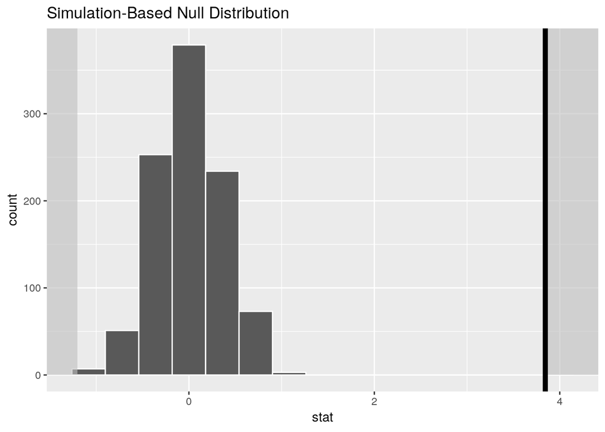

The plot shows us the distribution of the test statistic for the 1000 randomized samples. The test statistic value for our sample is represented by a black line. The two-sided p-value regions are marked by a grey background. If our null hypothesis were true, then the test statistic value of our sample would be somewhere in the distribution of the test statistic for the randomized samples. Every test statistic value for a randomized sample, which lies in the p-value region, increases the p-value.

As we can see the test statistic value of our sample is pretty far away from the test statistic values of the randomized samples. This already shows, without looking at the p-value itself, that the profit oriented recommendation system causes a significant difference in the sales in Euro. The value of the p-value is 0, which reaffirms our interpretation of the plot.

Now, we look at the confidence interval:

| 2.5% | 97.5% |
| --- | --- |
| 3.236891 | 4.401805 |

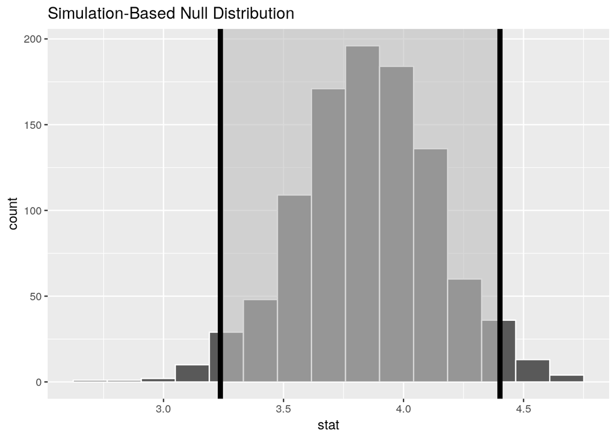

As we can see, there is a 95% chance that for the global population customers, who get profit oriented recommendations, spend on average 3.24€-4.4€ more than people who get random recommendations.

## 5.2 The Ranking Based Recommendation System

Now we do an inference analysis for the ranking based recommendation system. Firstly, we look at the p-value and the corresponding plot:

```
## [1] "p-value = 0.088"
```

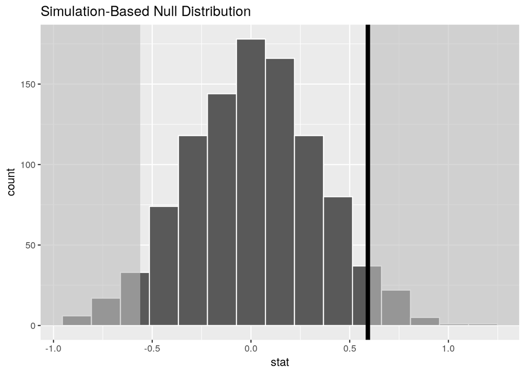

In this plot quite some portions of the distribution of the test statistic for our random samples lie in the p-value zone. This is also shown by the p-value 0.088, which greater than 0.025. This means that for our alpha = 0.05 the effect of the ranking based recommendation system is statistically insignificant.

Now we look at the confidence interval:

| 2.5% | 97.5% |
| --- | --- |
| -0.0582687 | 1.200044 |

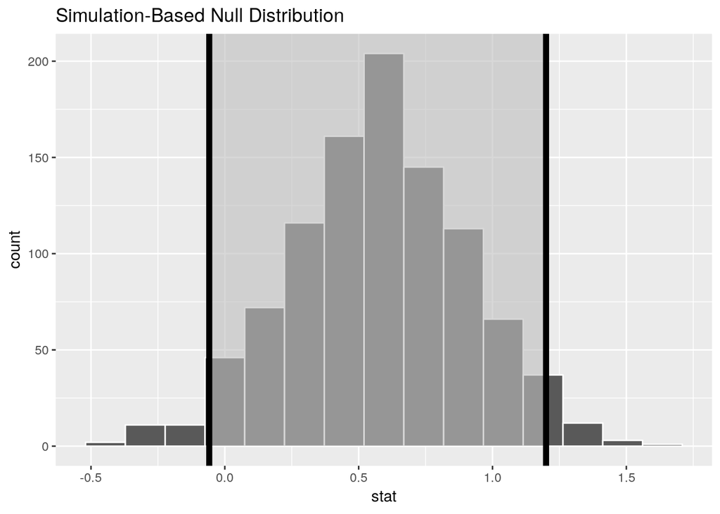

Since the confidence interval includes the value 0, it shows us that the effect is statistically insignificant.

## 5.3 Summary

To sum it up, the company should use the profit oriented recommendation system, since out of the two tested systems it causes the largest increase in sales. The ranking based recommendation system does not cause any statistically relevant difference in sales. However if the effect was something else than sales in Euro per person, then the results could be different. The company should ask itself if the goal of their recommendation system should really be to increase sales. Maybe at some point in time it could introduce a subscription business model, similar to that of Amazon. In that case it might also want to increase the percentage of customers that have a subscription.

# 6 Creating a Model

# 7 Summary